# Coding HW13

Yue Gu

2/20/2022

Follow the below instructions and turn in both your code and results:

1. Load the `dengue.csv` file provided to you, or from [this site](https://vincentarelbundock.github.io/Rdatasets/csv/DAAG/dengue.csv). Documentation on the variables is available [here](https://vincentarelbundock.github.io/Rdatasets/doc/DAAG/dengue.html).

*Language-specific instructions*:

- In R or Python, store the data set as `dengue`
- In Stata, some of the variables will be read as text. Use `destring *, replace force` to turn them numeric.

```r
dengue <- read.csv("/Users/luna/Desktop/dengue.csv")
```

2. Run an OLS regression using average humidity to predict whether dengue was observed in the area, and look at the results.

```r
library(tidyverse); library(modelsummary)
m2 <- lm(NoYes ~ humid, data = dengue)
msummary(list(m2), stars = TRUE)
```

|  | Model 1 |
| --- | --- |
| (Intercept) | −0.416*** |
|  | (0.018) |
| humid | 0.050*** |
|  | (0.001) |
| Num.Obs. | 1998 |
| R2 | 0.548 |
| R2 Adj. | 0.548 |
| AIC | 1258.9 |
| BIC | 1275.7 |
| Log.Lik. | −626.466 |
| F | 2424.483 |

+ p < 0.1, * p < 0.05, ** p < 0.01, *** p < 0.001

*Language-specific instructions*:

- In both R and Python, save the model as `m2`. In R, use the `msummary()` function from the **modelsummary** package to display the results with the `stars = TRUE` option.
3. Write two sentences, one interpreting the intercept and one interpreting the slope.

The coefficient on the intercept is the expected mean when the independent variable humid is zero, indicating that when humidity is 0, the average probability of observing dengue in the area is −0.416.

The coefficient on humid is the estimated slope indicating that one-unit increase in humidity is associated with a 0.050-unit increase in the probability of observing dengue in the area.

4. Get a set of summary statistics for the humidity variable and write a comment on how this can help you make sense of the intercept in the regression from step 2.

*Language-specific instructions*:

- We didn’t cover easy summary statistics commands in the book. In R you can use `summary()` on the variable. In Stata try `summarize` and in Python, `data['variablename'].describe()`.

```r
summary(dengue$humid)
```

```
##    Min. 1st Qu.  Median    Mean 3rd Qu.    Max.    NA's
##  0.6714 10.0088 16.1433 16.7013 23.6184 30.2665       2
```

```r
summary(dengue$NoYes)
```

```
##    Min. 1st Qu.  Median    Mean 3rd Qu.    Max.
##  0.0000  0.0000  0.0000  0.4155  1.0000  1.0000
```

The summary statistics shows that the minimum value of humidity in the data is 0.6714 which is above 0 and that binary variable NoYes can either be 0 or 1. The prediction by our model where NoYes=−0.416 (the estimated coefficient on the intercept in step 2) when humidity=0 cannot be actually observed in the real world. This tells us that the intercept in the regression does not always make sense in the reality. In reality, the values that the dependent variable takes depend on the range of possible values that the independent variable(s) could take.

5. We might recognize that, if we’re interested in the effect of humidity on Dengue, temperature might be on a back door. Add a control for temperature, rerun the regression, and show the results.

*Language-specific instructions*:

- In both R and Python, save the model as `m5`. In R, use the `msummary()` function from the **modelsummary** package to display the results with the `stars = TRUE` option.

```r
m5 <- lm(NoYes ~ humid + temp, data = dengue)
msummary(list(m5), stars = TRUE)
```

|  | Model 1 |
| --- | --- |
| (Intercept) | −0.407*** |
|  | (0.019) |
| humid | 0.053*** |
|  | (0.002) |
| temp | −0.003+ |
|  | (0.002) |
| Num.Obs. | 1998 |
| R2 | 0.549 |
| R2 Adj. | 0.549 |
| AIC | 1257.5 |
| BIC | 1279.9 |
| Log.Lik. | −624.758 |
| F | 1215.415 |

+ p < 0.1, * p < 0.05, ** p < 0.01, *** p < 0.001

6. Our dependent variable is binary, and we’re getting predictions below zero, which we might not want. Rerun the regression from question 5 but as a logit model, and report the marginal effects of both slope coefficients.

*Language-specific instructions*:

- In both R and Python, save the model as `m6`. In R, use the `msummary()` function from the **modelsummary** package to display the results with the `stars = TRUE` option.

```r
library(margins)
```

```r
m6 <- glm(NoYes ~ humid + temp, data = dengue, family = binomial(link = 'logit'))

msummary(list(m6), stars = TRUE)
```

|  | Model 1 |
| --- | --- |
| (Intercept) | −6.592*** |
|  | (0.303) |
| humid | 0.305*** |
|  | (0.020) |
| temp | 0.040* |
|  | (0.019) |
| Num.Obs. | 1998 |
| AIC | 1363.0 |
| BIC | 1379.8 |
| Log.Lik. | −678.519 |
| F | 303.674 |

+ p < 0.1, * p < 0.05, ** p < 0.01, *** p < 0.001

```r
m6 %>%
    margins() %>%
    summary()
```

```
##  factor    AME     SE       z      p  lower  upper
##   humid 0.0317 0.0015 20.4727 0.0000 0.0287 0.0348
##    temp 0.0042 0.0020  2.0612 0.0393 0.0002 0.0081
```

The marginal effects of the coefficient on humid is 0.0317 and the marginal effects of the coefficient on temp is 0.0042.

7. A long one: Now let’s say we’re directly interested in the relationship between temperature and humidity. Run an OLS regression of humidity on temperature. Calculate the residuals of that regression, and then make a plot that will let you evaluate whether there is likely heteroskedasticity in the model. Rerun the model with heteroskedasticity-robust standard errors. Show both models, and say whether you think there is heteroskedasticity

*Language-specific instructions*:

- In both R and Python, save the model as `m7`, and `m7b` if you rerun with robust standard errors.

In R, use `filter(!is.na(dengue$humid))` on the data before running the model so the residuals line up properly. Use the `msummary()` function from the **modelsummary** package to display the results with the `stars = TRUE` option. Also, if you’re clever about `msummary()` usage, you can skip creating `m7b`. You can access residuals using `resid(m7)`.

In Stata, you can access residuals using `predict resid, r` after running the model.

In Python, use `dengue.loc[~pd.isna(dengue['humid'])]` on the data before running the model so the residuals line up properly. You can access residuals using `m7.resid`.

```r
dengue_1 <- dengue %>%
  filter(!is.na(dengue$humid))

m7 <- glm(humid ~ temp, data = dengue_1)
msummary(list(m7), stars = TRUE)
```

|  | Model 1 |
| --- | --- |
| (Intercept) | 2.362*** |
|  | (0.211) |
| temp | 0.779*** |
|  | (0.011) |
| Num.Obs. | 1998 |
| AIC | 10998.5 |
| BIC | 11015.3 |
| Log.Lik. | −5496.246 |
| F | 5483.194 |

+ p < 0.1, * p < 0.05, ** p < 0.01, *** p < 0.001

```r
residuals <- resid(m7)
```

```r
library(ggplot2)
library(dplyr)
```

```r
dengue_2 <- dengue_1 %>%
  mutate(resi = residuals)
```

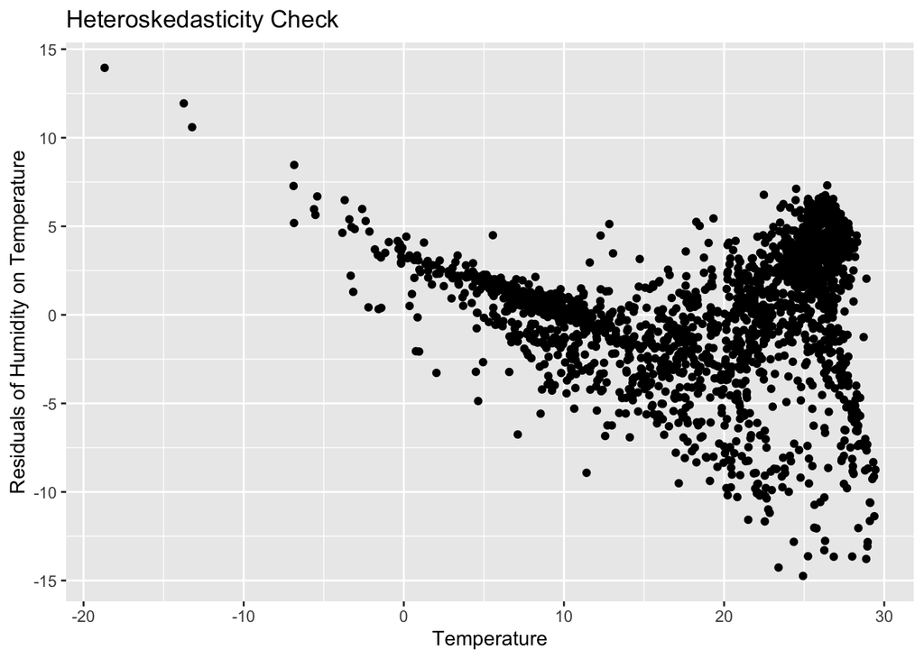

```r
ggplot(data = dengue_2, mapping = aes(x = temp, y = resi)) +
  geom_point()+
  labs(x = "Temperature", y = "Residuals of Humidity on Temperature", title = "Heteroskedasticity Check")
```

The plot of the relationship between temperature and residuals indicates that the error distribution isnʼt identical because the variance of the distribution changes with values of the variables in the model. So there is likely to be a heteroskedasticity in the model.

```r
library(AER); library(sandwich); library(fixest)
msummary(m7, vcov = "robust", stars = c('*' = .1, '**' = .05, '***' = .01))
```

|  | Model 1 |
| --- | --- |
| (Intercept) | 2.362*** |
|  | (0.197) |
| temp | 0.779*** |
|  | (0.012) |
| Num.Obs. | 1998 |
| AIC | 10998.5 |
| BIC | 11015.3 |
| Log.Lik. | −5496.246 |
| F | 4534.637 |
| Std.Errors | Robust |

* p < 0.1, ** p < 0.05, *** p < 0.01

8. In the graph in the last problem you may have noticed that for certain ranges of temperate, the errors were clearly nonzero on average. This can indicate a functional form problem. Run the model from question 7 again (with heteroskedasticity-robust standard errors), but this time use the logarithm of humidity in place of humidity. Add a sentence interpreting the coefficient on temperature.

*Language-specific instructions*:

- In Python and R, store the model as `m8`. In R, use the `msummary()` function from the **modelsummary** package to display the results with the `stars = TRUE` option.

In Stata, you’ll need to create logged humidity in the data before running the regression. In R and Python you can do it inside of the regression formula, using `np.log()` from **numpy** in Python.

```r
m8 <- lm(log(humid) ~ temp, data = dengue_1)
msummary(m8, vcov = "robust", stars = c('*' = .1, '**' = .05, '***' = .01))
```

|  | Model 1 |
| --- | --- |
| (Intercept) | 1.659*** |
|  | (0.018) |
| temp | 0.056*** |
|  | (0.001) |
| Num.Obs. | 1998 |
| R2 | 0.770 |
| R2 Adj. | 0.770 |
| AIC | 116.1 |
| BIC | 132.9 |
| Log.Lik. | −55.027 |
| F | 4048.470 |
| Std.Errors | Robust |

* p < 0.1, ** p < 0.05, *** p < 0.01

The coefficient on temperature indicates that a one-unit increase in temperature would lead to a 5.6% increase in humidity.

9. Bonus challenge: figure out how I decided on a form where you log humidity and keep temperature linear.

The logarithm is handy for turning multiplicative relationships like this into additive linear ones, since log(XY) = log(X) + log(Y).